# Лабораторная работа 3. Перенос знаний с использованием PyTorch

# Выполнил: Уткин Г.В. (гр. 3823М1ПМкн)

# Цель работы

Цель данной работы — изучить и реализовать метод переноса знаний (transfer learning) в глубоких нейронных сетях для решения задачи классификации отходов на основе набора данных [Garbage Classification](https://www.kaggle.com/datasets/asdasdasasdas/garbage-classification). Предлагается применение метода переноса знаний к известным моделям глубокого обучения, обученных на наборе данных ImageNet.

# Перенос знаний

Перенос знаний — это метод, который позволяет улучшить сходимость модели на новых данных за счет лучшей начальной инициализации модели. В качестве начальной инициализации в таком случае выступают веса полученной на исходном наборе данных. Этот подход часто применяется в задачах, где имеется мало данных, но есть смежный набор данных с обученной моделью.

Данный подход предполагает использование весов нейронной сети, обученной на одних данных, для начальной инициализации весов в другой, смежной задаче. В задачах классификации этот подход обычно предполагает изменение последнего слоя, поскольку количество нейронов в последнем слое определяется количеством классов в исходном наборе данных. Например, модель, обученная на ImageNet, будет иметь 1000 нейронов на последнем слое, а модель, обученная на MNIST, будет иметь 10 нейронов. Существуют различные подходы к переносу знаний:

- Обучение всех весов нейронной сети
- Обучение весов слоев, которые были добавлены или изменены
- Обучение нескольких последних слоев
- Обучение части слоев нейронной сети

Любая подобная конфигурация является допустимой и может помочь в решении задачи. Для определения наилучшей конфигурации необходимо провести эксперименты.

В задачах классификации последний слой обычно заменяют на один или несколько слоев. Количество нейроннов в последнем слое при это должно быть равно количеству классов в новом наборе данных. Вместо последнего слоя также можно использовать классические модели машинного обучения, данный подход нельзя использовать в этой лабораторной работе!

# Требования

1. Необходимо выполнить и отобразить в Jupyter следующие задачи:
   - Загрузить и проверить данные, включая демонстрацию избранных изображений и меток классов для подтверждения корректности загрузки и совпадения размерностей.
   - Загрузить 4 нейронные сети (можно использовать torchvision), обученные на наборе данных ImageNet. Требуется для каждой модели провести 2 эксперимента, используя разные конфигурация переноса знаний. Модифицировать последний слой и реализовать обучение на наборе данных Garbage Classification. Настроить гиперпараметры обучения.
   - Построить F1-score от количества эпох для всех моделей на валидационных данных. Построить сравнительную столбчатую диаграмму точностей: модель и тип эксперимента (с кратким указанием параметров) по горизонтали, F1 score на тестовых данных по вертикали.
2. Проверка корректности:
   - Разделите датасет на тренировочную, валидационную и тестовую выборки самостоятельно в соотношении 70/15/15.
   - Для оценки качества следует использовать Macro F1-score, поскольку датасет не сбалансирован.
3. Архитектуры:
   - Можно использовать любые сверточные архитектуры или архитектуры на базе механизма внимания (transformer, ViT).
   - Хорошее понимание работы выбранных архитектур напрямую влияет на количество баллов за "знание". Будьте готовы кратко рассказать о примечательных особенностях выбранных или одной из выбранных архитектур при очной сдаче лабораторной работы. Не бойтесь выбирать сложные архитектуры - чем сложнее архитектура, тем больше шансов рассказать про нее что-то интересное и примечательное.

# Оценивание

Максимальное количество баллов - 30 баллов:

По 2 балла за каждую реализацию transfer learning (максимальное количество моделей - 4, по каждой модели 2 типа экспериментов, 4 * 2 * 0.625 = 5 баллов). 0.1* за достигнутые результаты качества классификации 15 баллов за обсуждение и демонстрацию понимания основных концепций работы.

## Необходимые библиотеки и гипперпараметры

```python
import torch
import torchvision
from torchvision import models
import torchvision.transforms as transforms
import torch.nn as nn
import torch.optim as optim
from torch.utils.data import DataLoader, random_split
import matplotlib.pyplot as plt
import numpy as np
from sklearn.metrics import f1_score
from torch.utils.data import Subset
from time import time
from sklearn.model_selection import train_test_split

epochs = 20
learning_rate = 0.001
batch_len = 64
classes = ['cardboard', 'glass', 'metal', 'paper', 'plastic', 'trash']
```

## Загрузка и подготовка датасета

```python
transform = transforms.Compose([
    transforms.Resize((128, 128)),
    transforms.ToTensor(),
    #transforms.Normalize([0.5, 0.5, 0.5], [0.5, 0.5, 0.5])
    transforms.Normalize([0.485, 0.456, 0.406], [0.229, 0.224, 0.225])
])

dataset = torchvision.datasets.ImageFolder(root='/content/drive/MyDrive/archive/Garbage-classification/Garbage-classification', transform=transform)
print(f'Size of dataset: ', len(dataset))

def split_dataset(dataset, train_ratio = 0.7, val_ratio = 0.15):
    total_size = len(dataset)
    indices = np.arange(total_size)
    np.random.shuffle(indices)

    train_end = int(train_ratio * total_size)
    val_end = train_end + int(val_ratio * total_size)

    train_indices = indices[:train_end]
    val_indices = indices[train_end:val_end]
    test_indices = indices[val_end:]

    train_subset = Subset(dataset, train_indices)
    val_subset = Subset(dataset, val_indices)
    test_subset = Subset(dataset, test_indices)

    return train_subset, val_subset, test_subset

train_dataset, val_dataset, test_dataset = split_dataset(dataset)

train_loader = DataLoader(train_dataset, batch_size = batch_len, shuffle = True)
val_loader = DataLoader(val_dataset, batch_size = batch_len, shuffle = False)
test_loader = DataLoader(test_dataset, batch_size = batch_len, shuffle = False)

print(f"size of train loader: ", len(train_dataset))
print(f"size of validation loader: ", len(val_dataset))
print(f"size of test loader: ", len(test_dataset))
```

```
Size of dataset:  2527
size of train loader:  1768
size of validation loader:  379
size of test loader:  380
```

## Визуализируем данные

[figure not shown]

```python
def show_images_with_labels(images, labels, classes, cols = 4):
    images = images / 2.0 + 0.5
    np_images = images.numpy()
    np_images = np.clip(np_images, 0, 1)
    num_images = len(images)
    rows = num_images // cols + (num_images % cols > 0)

    fig, axes = plt.subplots(rows, cols, figsize = (cols * 2, rows * 2))
    axes = axes.flatten()

    for i in range(num_images):
        img = np.transpose(np_images[i], (1, 2, 0))
        axes[i].imshow(img)
        axes[i].axis('off')
        axes[i].set_title(classes[labels[i]], fontsize = 10)

    for i in range(num_images, len(axes)):
        axes[i].axis('off')

    plt.tight_layout()
    plt.show()

dataiter = iter(train_loader)
images, labels = next(dataiter)

show_images_with_labels(images, labels, dataset.classes)
```

## Архитектуры

Рассмотрим следующие архитектуры для обучения свёрточных нейронных сетей:

- ResNet-50
- VGG-16
- GoogLeNet
- shufflenet_v2

```python
def model_device(model):
    return next(model.parameters()).device

@torch.no_grad()
def get_f1(model, dataloader: DataLoader):
    device = model_device(model)
    f1_all = []
    model.eval()
    for images, labels in dataloader:
        images, labels = images.to(device), labels.to(device)
        outputs = model(images)
        _, preds = torch.max(outputs, 1)
        f1 = f1_score(labels.cpu(), preds.cpu(), average="macro")
        f1_all.append(f1)
    return sum(f1_all) / len(f1_all)

@torch.no_grad()
def get_accuracy(model, dataloader: DataLoader):
    device = model_device(model)
    correct = 0
    total = 0
    model.eval()
    for images, labels in dataloader:
        images, labels = images.to(device), labels.to(device)
        outputs = model(images)
        _, preds = torch.max(outputs, 1)
        correct += (preds == labels).sum().item()
        total += labels.size(0)
    return correct / total

def go_train(model, name, train_loader, val_loader, epochs, learning_rate):
    device = model_device(model)
    optimizer = torch.optim.Adam(filter(lambda param: param.requires_grad, model.parameters()), lr=learning_rate)
    criterion = nn.CrossEntropyLoss()
    best_f1 = 0.0
    val_f1_stat = []

    for epoch in range(epochs):
        model.train()
        start_time = time()
        total_train_correct = 0
        total_train = 0
        for images, labels in train_loader:
            images, labels = images.to(device), labels.to(device)
            optimizer.zero_grad()
            outputs = model(images)
            loss = criterion(outputs, labels)
            loss.backward()
            optimizer.step()

            _, preds = torch.max(outputs, 1)
            total_train_correct += (preds == labels).sum().item()
            total_train += labels.size(0)

        train_accuracy = total_train_correct / total_train
        train_time = time() - start_time

        start_time = time()
        val_f1 = get_f1(model, val_loader)
        val_accuracy = get_accuracy(model, val_loader)
        val_time = time() - start_time

        if val_f1 > best_f1:
            torch.save(model.state_dict(), f"best_{name}.pth")
            best_f1 = val_f1

        val_f1_stat.append(val_f1)

        print(f"Epoch {epoch + 1}: Train time {train_time:.2f} s, Train Accuracy {train_accuracy:.2f}, "
              f"Validation time {val_time:.2f} s, Validation F1 {val_f1:.2f}, Validation Accuracy {val_accuracy:.2f}")

    test_accuracy = get_accuracy(model, test_loader)
    print(f"Test Accuracy: {test_accuracy:.2f}")

    return val_f1_stat

test_f1_stat = {}

def experiment(model_factory):
    global test_f1_stat
    model = model_factory(len(classes)).to(device)
    name = model_factory.__name__
    val_f1_stat = go_train(model, name, train_loader, val_loader, epochs, learning_rate)
    model.load_state_dict(torch.load(f"best_{name}.pth", weights_only=True))
    test_f1 = get_f1(model, test_loader)
    print("Test F1:", test_f1)
    plt.plot(range(epochs), val_f1_stat, marker="o")
    plt.title(f"{name} validation")
    plt.xlabel("epoch")
    plt.xticks([i for i in range(epochs)])
    plt.ylabel("F1 score")
    plt.grid()
    plt.show()
    test_f1_stat[name] = test_f1

assert torch.cuda.is_available(), "CUDA backend must be available"
device = torch.device("cuda")
print(device)
```

```
cuda
```

### ResNet-50

```python
def resnet50_exp1(num_classes: int):
    model = models.resnet50(weights=models.ResNet50_Weights.DEFAULT)
    model.fc = nn.Linear(model.fc.in_features, num_classes)
    return model

def resnet50_exp2(num_classes: int):
    model = models.resnet50(weights=models.ResNet50_Weights.DEFAULT)

    for param in model.parameters():
        param.requires_grad = False

    model.fc = nn.Sequential(
        nn.BatchNorm1d(model.fc.in_features),
        nn.Linear(model.fc.in_features, 1024),
        nn.LeakyReLU(0.1),
        nn.Dropout(0.4),
        nn.Linear(1024, 512),
        nn.LeakyReLU(0.1),
        nn.Linear(512, num_classes)
    )

    return model
```

```
Epoch 1: Train time 222.33 s, Train Accuracy 0.73, Validation time 52.41 s, Validation F1 0.63, Validation Accuracy 0.68
Epoch 2: Train time 16.96 s, Train Accuracy 0.89, Validation time 5.69 s, Validation F1 0.79, Validation Accuracy 0.83
Epoch 3: Train time 16.90 s, Train Accuracy 0.95, Validation time 5.55 s, Validation F1 0.75, Validation Accuracy 0.80
Epoch 4: Train time 16.73 s, Train Accuracy 0.95, Validation time 5.10 s, Validation F1 0.79, Validation Accuracy 0.83
Epoch 5: Train time 16.86 s, Train Accuracy 0.97, Validation time 5.93 s, Validation F1 0.79, Validation Accuracy 0.82
Epoch 6: Train time 16.97 s, Train Accuracy 0.97, Validation time 5.32 s, Validation F1 0.77, Validation Accuracy 0.80
Epoch 7: Train time 16.87 s, Train Accuracy 0.96, Validation time 5.44 s, Validation F1 0.81, Validation Accuracy 0.87
Epoch 8: Train time 16.92 s, Train Accuracy 0.99, Validation time 5.69 s, Validation F1 0.82, Validation Accuracy 0.85
Epoch 9: Train time 16.75 s, Train Accuracy 0.99, Validation time 5.28 s, Validation F1 0.74, Validation Accuracy 0.79
Epoch 10: Train time 16.48 s, Train Accuracy 0.98, Validation time 5.85 s, Validation F1 0.78, Validation Accuracy 0.81
Epoch 11: Train time 16.57 s, Train Accuracy 0.99, Validation time 5.32 s, Validation F1 0.74, Validation Accuracy 0.79
Epoch 12: Train time 16.83 s, Train Accuracy 0.97, Validation time 5.67 s, Validation F1 0.78, Validation Accuracy 0.83
Epoch 13: Train time 16.79 s, Train Accuracy 0.97, Validation time 5.56 s, Validation F1 0.76, Validation Accuracy 0.78
Epoch 14: Train time 16.77 s, Train Accuracy 0.99, Validation time 5.38 s, Validation F1 0.83, Validation Accuracy 0.85
Epoch 15: Train time 16.97 s, Train Accuracy 1.00, Validation time 5.92 s, Validation F1 0.81, Validation Accuracy 0.85
Epoch 16: Train time 16.47 s, Train Accuracy 1.00, Validation time 5.14 s, Validation F1 0.83, Validation Accuracy 0.85
Epoch 17: Train time 17.24 s, Train Accuracy 0.99, Validation time 5.81 s, Validation F1 0.75, Validation Accuracy 0.78
Epoch 18: Train time 16.67 s, Train Accuracy 0.99, Validation time 5.69 s, Validation F1 0.76, Validation Accuracy 0.83
Epoch 19: Train time 16.66 s, Train Accuracy 0.99, Validation time 5.19 s, Validation F1 0.77, Validation Accuracy 0.81
Epoch 20: Train time 16.56 s, Train Accuracy 0.99, Validation time 5.91 s, Validation F1 0.74, Validation Accuracy 0.79
Test Accuracy: 0.78
Test F1: 0.800494130637861
```

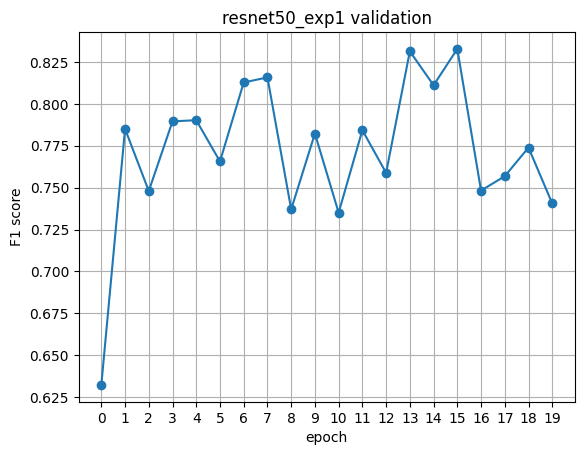

```python
experiment(resnet50_exp1)
```

```
Epoch 1: Train time 12.88 s, Train Accuracy 0.66, Validation time 5.29 s, Validation F1 0.72, Validation Accuracy 0.77
Epoch 2: Train time 13.32 s, Train Accuracy 0.88, Validation time 5.18 s, Validation F1 0.76, Validation Accuracy 0.80
Epoch 3: Train time 13.41 s, Train Accuracy 0.94, Validation time 6.00 s, Validation F1 0.71, Validation Accuracy 0.78
Epoch 4: Train time 12.91 s, Train Accuracy 0.96, Validation time 5.20 s, Validation F1 0.74, Validation Accuracy 0.78
Epoch 5: Train time 12.85 s, Train Accuracy 0.96, Validation time 5.22 s, Validation F1 0.73, Validation Accuracy 0.77
Epoch 6: Train time 13.05 s, Train Accuracy 0.96, Validation time 6.26 s, Validation F1 0.72, Validation Accuracy 0.77
Epoch 7: Train time 13.14 s, Train Accuracy 0.95, Validation time 5.42 s, Validation F1 0.76, Validation Accuracy 0.80
Epoch 8: Train time 13.05 s, Train Accuracy 0.97, Validation time 5.48 s, Validation F1 0.74, Validation Accuracy 0.78
Epoch 9: Train time 12.67 s, Train Accuracy 0.98, Validation time 6.03 s, Validation F1 0.76, Validation Accuracy 0.79
Epoch 10: Train time 13.09 s, Train Accuracy 0.97, Validation time 5.33 s, Validation F1 0.73, Validation Accuracy 0.79
Epoch 11: Train time 13.45 s, Train Accuracy 0.97, Validation time 5.61 s, Validation F1 0.76, Validation Accuracy 0.80
Epoch 12: Train time 13.17 s, Train Accuracy 0.98, Validation time 6.14 s, Validation F1 0.75, Validation Accuracy 0.80
Epoch 13: Train time 13.32 s, Train Accuracy 0.98, Validation time 5.22 s, Validation F1 0.75, Validation Accuracy 0.78
Epoch 14: Train time 13.23 s, Train Accuracy 0.97, Validation time 5.66 s, Validation F1 0.74, Validation Accuracy 0.79
Epoch 15: Train time 12.95 s, Train Accuracy 0.98, Validation time 5.87 s, Validation F1 0.75, Validation Accuracy 0.79
Epoch 16: Train time 13.48 s, Train Accuracy 0.98, Validation time 5.69 s, Validation F1 0.75, Validation Accuracy 0.80
Epoch 17: Train time 13.97 s, Train Accuracy 0.98, Validation time 6.24 s, Validation F1 0.77, Validation Accuracy 0.81
Epoch 18: Train time 14.18 s, Train Accuracy 0.98, Validation time 5.53 s, Validation F1 0.76, Validation Accuracy 0.79
Epoch 19: Train time 13.90 s, Train Accuracy 0.98, Validation time 6.00 s, Validation F1 0.75, Validation Accuracy 0.79
Epoch 20: Train time 14.17 s, Train Accuracy 0.98, Validation time 6.19 s, Validation F1 0.74, Validation Accuracy 0.80
Test Accuracy: 0.83
Test F1: 0.7881193445375247
```

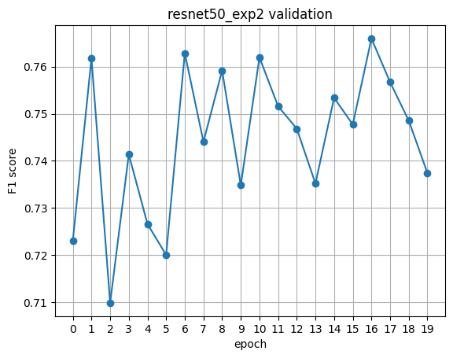

```python
experiment(resnet50_exp2)
```

### VGG-16

```python
def vgg16_exp1(num_classes: int):
    model = models.vgg16(weights=models.VGG16_Weights.DEFAULT)
    for param in model.features.parameters():
        param.requires_grad = False
    for param in model.features[-6:].parameters():
        param.requires_grad = True

    model.classifier[6] = nn.Linear(model.classifier[6].in_features, num_classes)

    return model

def vgg16_exp2(num_classes: int):
    model = models.vgg16(weights=models.VGG16_Weights.DEFAULT)
    for param in model.parameters():
        param.requires_grad = False
    for param in model.features[24:].parameters():
        param.requires_grad = True

    model.avgpool = nn.Sequential(
        nn.Conv2d(512, 256, kernel_size=3, padding=1),
        nn.BatchNorm2d(256),
        nn.ReLU(),
        nn.AdaptiveAvgPool2d((7, 7)),
    )

    model.classifier = nn.Sequential(
        nn.Linear(256 * 7 * 7, 512),
        nn.ReLU(),
        nn.BatchNorm1d(512),
        nn.Linear(512, num_classes)
    )
    return model
```

```
Epoch 1: Train time 15.44 s, Train Accuracy 0.52, Validation time 6.48 s, Validation F1 0.53, Validation Accuracy 0.61
Epoch 2: Train time 16.17 s, Train Accuracy 0.72, Validation time 5.96 s, Validation F1 0.70, Validation Accuracy 0.76
Epoch 3: Train time 15.48 s, Train Accuracy 0.78, Validation time 5.60 s, Validation F1 0.68, Validation Accuracy 0.73
Epoch 4: Train time 15.07 s, Train Accuracy 0.83, Validation time 6.17 s, Validation F1 0.74, Validation Accuracy 0.79
Epoch 5: Train time 15.48 s, Train Accuracy 0.89, Validation time 5.73 s, Validation F1 0.72, Validation Accuracy 0.78
Epoch 6: Train time 15.56 s, Train Accuracy 0.92, Validation time 5.93 s, Validation F1 0.72, Validation Accuracy 0.75
Epoch 7: Train time 15.13 s, Train Accuracy 0.89, Validation time 5.56 s, Validation F1 0.76, Validation Accuracy 0.79
Epoch 8: Train time 15.60 s, Train Accuracy 0.92, Validation time 5.49 s, Validation F1 0.78, Validation Accuracy 0.81
Epoch 9: Train time 16.04 s, Train Accuracy 0.95, Validation time 5.81 s, Validation F1 0.79, Validation Accuracy 0.79
Epoch 10: Train time 15.33 s, Train Accuracy 0.92, Validation time 6.12 s, Validation F1 0.73, Validation Accuracy 0.79
Epoch 11: Train time 14.61 s, Train Accuracy 0.94, Validation time 5.36 s, Validation F1 0.73, Validation Accuracy 0.80
Epoch 12: Train time 14.85 s, Train Accuracy 0.94, Validation time 6.19 s, Validation F1 0.76, Validation Accuracy 0.80
Epoch 13: Train time 14.87 s, Train Accuracy 0.94, Validation time 5.42 s, Validation F1 0.76, Validation Accuracy 0.77
Epoch 14: Train time 14.65 s, Train Accuracy 0.95, Validation time 6.09 s, Validation F1 0.79, Validation Accuracy 0.83
Epoch 15: Train time 15.59 s, Train Accuracy 0.97, Validation time 5.42 s, Validation F1 0.77, Validation Accuracy 0.80
Epoch 16: Train time 14.96 s, Train Accuracy 0.96, Validation time 6.08 s, Validation F1 0.74, Validation Accuracy 0.79
Epoch 17: Train time 14.86 s, Train Accuracy 0.94, Validation time 5.54 s, Validation F1 0.71, Validation Accuracy 0.75
Epoch 18: Train time 14.98 s, Train Accuracy 0.93, Validation time 5.83 s, Validation F1 0.73, Validation Accuracy 0.78
Epoch 19: Train time 14.75 s, Train Accuracy 0.96, Validation time 5.51 s, Validation F1 0.76, Validation Accuracy 0.79
Epoch 20: Train time 14.75 s, Train Accuracy 0.95, Validation time 5.88 s, Validation F1 0.80, Validation Accuracy 0.84
Test Accuracy: 0.83
Test F1: 0.7731591663396019
```

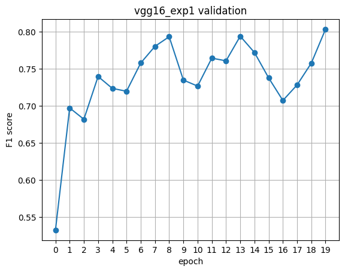

```python
experiment(vgg16_exp1)
```

```
Epoch 1: Train time 14.06 s, Train Accuracy 0.67, Validation time 5.66 s, Validation F1 0.46, Validation Accuracy 0.57
Epoch 2: Train time 14.29 s, Train Accuracy 0.86, Validation time 5.86 s, Validation F1 0.81, Validation Accuracy 0.84
Epoch 3: Train time 14.31 s, Train Accuracy 0.94, Validation time 5.46 s, Validation F1 0.75, Validation Accuracy 0.78
Epoch 4: Train time 13.87 s, Train Accuracy 0.96, Validation time 5.61 s, Validation F1 0.76, Validation Accuracy 0.81
Epoch 5: Train time 13.73 s, Train Accuracy 0.98, Validation time 5.97 s, Validation F1 0.68, Validation Accuracy 0.73
Epoch 6: Train time 13.75 s, Train Accuracy 0.98, Validation time 5.47 s, Validation F1 0.77, Validation Accuracy 0.83
Epoch 7: Train time 14.02 s, Train Accuracy 0.98, Validation time 6.23 s, Validation F1 0.79, Validation Accuracy 0.80
Epoch 8: Train time 13.88 s, Train Accuracy 0.99, Validation time 5.50 s, Validation F1 0.80, Validation Accuracy 0.84
Epoch 9: Train time 13.97 s, Train Accuracy 1.00, Validation time 5.96 s, Validation F1 0.78, Validation Accuracy 0.83
Epoch 10: Train time 14.00 s, Train Accuracy 0.99, Validation time 5.58 s, Validation F1 0.81, Validation Accuracy 0.84
Epoch 11: Train time 14.16 s, Train Accuracy 0.99, Validation time 5.65 s, Validation F1 0.75, Validation Accuracy 0.80
Epoch 12: Train time 13.98 s, Train Accuracy 0.99, Validation time 5.91 s, Validation F1 0.75, Validation Accuracy 0.80
Epoch 13: Train time 13.93 s, Train Accuracy 0.99, Validation time 5.54 s, Validation F1 0.78, Validation Accuracy 0.84
Epoch 14: Train time 13.81 s, Train Accuracy 0.99, Validation time 6.06 s, Validation F1 0.79, Validation Accuracy 0.85
Epoch 15: Train time 14.00 s, Train Accuracy 1.00, Validation time 5.47 s, Validation F1 0.79, Validation Accuracy 0.84
Epoch 16: Train time 13.84 s, Train Accuracy 1.00, Validation time 6.29 s, Validation F1 0.82, Validation Accuracy 0.87
Epoch 17: Train time 14.17 s, Train Accuracy 1.00, Validation time 5.58 s, Validation F1 0.84, Validation Accuracy 0.88
Epoch 18: Train time 14.19 s, Train Accuracy 0.99, Validation time 5.98 s, Validation F1 0.74, Validation Accuracy 0.83
Epoch 19: Train time 14.04 s, Train Accuracy 0.99, Validation time 5.60 s, Validation F1 0.78, Validation Accuracy 0.82
Epoch 20: Train time 14.08 s, Train Accuracy 0.99, Validation time 5.89 s, Validation F1 0.70, Validation Accuracy 0.73
Test Accuracy: 0.78
Test F1: 0.8518767523041441
```

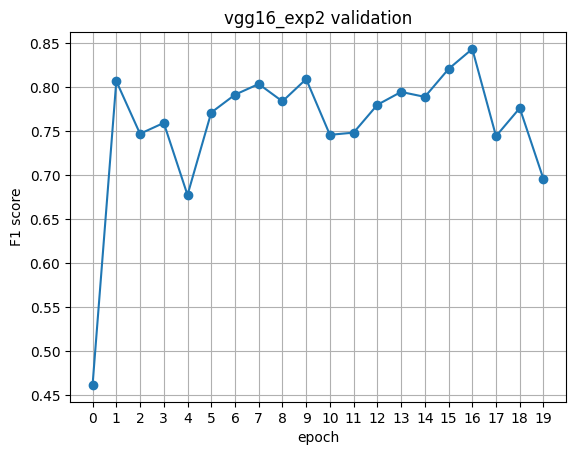

```python
experiment(vgg16_exp2)
```

### shufflenet

```python
def shufflenet_exp1(num_classes: int):
    model = models.shufflenet_v2_x1_0(weights=models.ShuffleNet_V2_X1_0_Weights.DEFAULT)
    model.fc = nn.Linear(model.fc.in_features, num_classes)
    return model

def shufflenet_exp2(num_classes: int):
    model = models.shufflenet_v2_x1_0(weights=models.ShuffleNet_V2_X1_0_Weights.DEFAULT)
    for param in model.parameters():
        param.requires_grad = False

    model.fc = nn.Sequential(
        nn.BatchNorm1d(model.fc.in_features),
        nn.Dropout(0.4),
        nn.Linear(model.fc.in_features, 256),
        nn.ReLU(),
        nn.BatchNorm1d(256),
        nn.Linear(256, num_classes)
    )
    return model
```

```
Downloading: "https://download.pytorch.org/models/shufflenetv2_x1-5666bf0f80.pth" to /root/.cache/torch/hub/checkpoints/shufflenetv2_x1-5666bf0f80.pth
```

```
Epoch 1: Train time 12.26 s, Train Accuracy 0.63, Validation time 4.50 s, Validation F1 0.66, Validation Accuracy 0.76
Epoch 2: Train time 12.22 s, Train Accuracy 0.81, Validation time 4.79 s, Validation F1 0.64, Validation Accuracy 0.73
Epoch 3: Train time 11.99 s, Train Accuracy 0.88, Validation time 5.23 s, Validation F1 0.75, Validation Accuracy 0.82
Epoch 4: Train time 11.68 s, Train Accuracy 0.93, Validation time 4.61 s, Validation F1 0.78, Validation Accuracy 0.84
Epoch 5: Train time 11.98 s, Train Accuracy 0.96, Validation time 4.50 s, Validation F1 0.78, Validation Accuracy 0.83
Epoch 6: Train time 11.91 s, Train Accuracy 0.97, Validation time 4.51 s, Validation F1 0.83, Validation Accuracy 0.86
Epoch 7: Train time 11.98 s, Train Accuracy 0.98, Validation time 4.95 s, Validation F1 0.82, Validation Accuracy 0.86
Epoch 8: Train time 11.77 s, Train Accuracy 0.98, Validation time 5.14 s, Validation F1 0.84, Validation Accuracy 0.88
Epoch 9: Train time 12.02 s, Train Accuracy 0.99, Validation time 4.39 s, Validation F1 0.80, Validation Accuracy 0.85
Epoch 10: Train time 11.98 s, Train Accuracy 0.99, Validation time 4.57 s, Validation F1 0.80, Validation Accuracy 0.84
Epoch 11: Train time 11.86 s, Train Accuracy 0.98, Validation time 4.37 s, Validation F1 0.78, Validation Accuracy 0.83
Epoch 12: Train time 11.66 s, Train Accuracy 0.99, Validation time 4.89 s, Validation F1 0.82, Validation Accuracy 0.86
Epoch 13: Train time 11.35 s, Train Accuracy 0.99, Validation time 4.81 s, Validation F1 0.79, Validation Accuracy 0.83
Epoch 14: Train time 11.43 s, Train Accuracy 0.99, Validation time 4.36 s, Validation F1 0.84, Validation Accuracy 0.86
Epoch 15: Train time 11.74 s, Train Accuracy 0.99, Validation time 4.41 s, Validation F1 0.83, Validation Accuracy 0.85
Epoch 16: Train time 11.56 s, Train Accuracy 0.99, Validation time 4.38 s, Validation F1 0.84, Validation Accuracy 0.88
Epoch 17: Train time 11.58 s, Train Accuracy 0.99, Validation time 4.65 s, Validation F1 0.85, Validation Accuracy 0.87
Epoch 18: Train time 11.15 s, Train Accuracy 0.99, Validation time 5.06 s, Validation F1 0.82, Validation Accuracy 0.86
Epoch 19: Train time 11.13 s, Train Accuracy 0.99, Validation time 4.63 s, Validation F1 0.84, Validation Accuracy 0.86
Epoch 20: Train time 11.52 s, Train Accuracy 0.99, Validation time 4.23 s, Validation F1 0.82, Validation Accuracy 0.84
Test Accuracy: 0.86
Test F1: 0.839188602701605
```

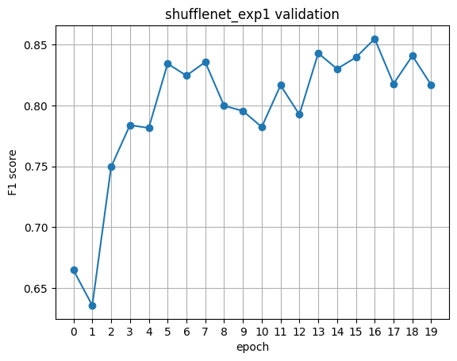

```python
experiment(shufflenet_exp1)
```

```
Epoch 1: Train time 10.81 s, Train Accuracy 0.65, Validation time 4.63 s, Validation F1 0.55, Validation Accuracy 0.63
Epoch 2: Train time 10.05 s, Train Accuracy 0.85, Validation time 4.81 s, Validation F1 0.78, Validation Accuracy 0.81
Epoch 3: Train time 10.13 s, Train Accuracy 0.88, Validation time 4.97 s, Validation F1 0.78, Validation Accuracy 0.83
Epoch 4: Train time 10.19 s, Train Accuracy 0.91, Validation time 4.70 s, Validation F1 0.78, Validation Accuracy 0.83
Epoch 5: Train time 10.58 s, Train Accuracy 0.92, Validation time 4.29 s, Validation F1 0.79, Validation Accuracy 0.84
Epoch 6: Train time 10.58 s, Train Accuracy 0.93, Validation time 4.25 s, Validation F1 0.80, Validation Accuracy 0.85
Epoch 7: Train time 10.57 s, Train Accuracy 0.93, Validation time 4.06 s, Validation F1 0.78, Validation Accuracy 0.83
Epoch 8: Train time 10.39 s, Train Accuracy 0.93, Validation time 4.14 s, Validation F1 0.78, Validation Accuracy 0.82
Epoch 9: Train time 10.70 s, Train Accuracy 0.95, Validation time 4.11 s, Validation F1 0.79, Validation Accuracy 0.84
Epoch 10: Train time 10.56 s, Train Accuracy 0.95, Validation time 4.10 s, Validation F1 0.78, Validation Accuracy 0.83
Epoch 11: Train time 10.46 s, Train Accuracy 0.95, Validation time 4.18 s, Validation F1 0.76, Validation Accuracy 0.82
Epoch 12: Train time 10.32 s, Train Accuracy 0.96, Validation time 4.47 s, Validation F1 0.77, Validation Accuracy 0.82
Epoch 13: Train time 9.81 s, Train Accuracy 0.96, Validation time 4.97 s, Validation F1 0.77, Validation Accuracy 0.84
Epoch 14: Train time 9.66 s, Train Accuracy 0.97, Validation time 4.85 s, Validation F1 0.79, Validation Accuracy 0.84
Epoch 15: Train time 9.77 s, Train Accuracy 0.97, Validation time 4.88 s, Validation F1 0.77, Validation Accuracy 0.82
Epoch 16: Train time 10.30 s, Train Accuracy 0.97, Validation time 4.52 s, Validation F1 0.79, Validation Accuracy 0.84
Epoch 17: Train time 10.58 s, Train Accuracy 0.97, Validation time 4.26 s, Validation F1 0.80, Validation Accuracy 0.83
Epoch 18: Train time 10.46 s, Train Accuracy 0.97, Validation time 4.06 s, Validation F1 0.81, Validation Accuracy 0.85
Epoch 19: Train time 10.25 s, Train Accuracy 0.98, Validation time 4.09 s, Validation F1 0.80, Validation Accuracy 0.84
Epoch 20: Train time 10.45 s, Train Accuracy 0.98, Validation time 4.14 s, Validation F1 0.81, Validation Accuracy 0.84
Test Accuracy: 0.87
Test F1: 0.8358538572248134
```

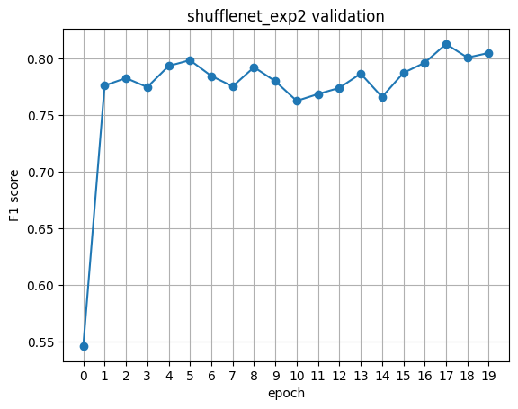

```python
experiment(shufflenet_exp2)
```

### GoogLeNet

```python
def googlenet_exp1(num_classes: int):
    model = models.googlenet(weights=models.GoogLeNet_Weights.DEFAULT)
    model.fc = nn.Linear(model.fc.in_features, num_classes)
    return model

def googlenet_exp2(num_classes: int):
    model = models.googlenet(weights=models.GoogLeNet_Weights.DEFAULT)
    for param in model.parameters():
        param.requires_grad = False
    for param in model.inception5b.parameters():
        param.requires_grad = True

    model.fc = nn.Sequential(
        nn.Linear(model.fc.in_features, 1024),
        nn.ReLU(),
        nn.BatchNorm1d(1024),
        nn.Dropout(0.5),
        nn.Linear(1024, num_classes)
    )
    return model
```

```
Downloading: "https://download.pytorch.org/models/googlenet-1378be20.pth" to /root/.cache/torch/hub/checkpoints/googlenet-1378be20.pth
```

```
Epoch 1: Train time 12.73 s, Train Accuracy 0.71, Validation time 4.89 s, Validation F1 0.76, Validation Accuracy 0.79
Epoch 2: Train time 12.52 s, Train Accuracy 0.89, Validation time 4.31 s, Validation F1 0.74, Validation Accuracy 0.81
Epoch 3: Train time 12.47 s, Train Accuracy 0.94, Validation time 4.64 s, Validation F1 0.79, Validation Accuracy 0.81
Epoch 4: Train time 12.22 s, Train Accuracy 0.96, Validation time 5.15 s, Validation F1 0.76, Validation Accuracy 0.82
Epoch 5: Train time 12.35 s, Train Accuracy 0.95, Validation time 4.43 s, Validation F1 0.82, Validation Accuracy 0.83
Epoch 6: Train time 12.32 s, Train Accuracy 0.95, Validation time 4.40 s, Validation F1 0.78, Validation Accuracy 0.82
Epoch 7: Train time 12.40 s, Train Accuracy 0.97, Validation time 4.78 s, Validation F1 0.82, Validation Accuracy 0.84
Epoch 8: Train time 12.01 s, Train Accuracy 0.97, Validation time 4.84 s, Validation F1 0.81, Validation Accuracy 0.83
Epoch 9: Train time 12.39 s, Train Accuracy 0.97, Validation time 4.38 s, Validation F1 0.77, Validation Accuracy 0.81
Epoch 10: Train time 12.20 s, Train Accuracy 0.97, Validation time 4.32 s, Validation F1 0.75, Validation Accuracy 0.80
Epoch 11: Train time 12.34 s, Train Accuracy 0.97, Validation time 4.92 s, Validation F1 0.78, Validation Accuracy 0.82
Epoch 12: Train time 12.21 s, Train Accuracy 0.97, Validation time 4.67 s, Validation F1 0.82, Validation Accuracy 0.85
Epoch 13: Train time 12.31 s, Train Accuracy 0.98, Validation time 4.33 s, Validation F1 0.80, Validation Accuracy 0.83
Epoch 14: Train time 12.39 s, Train Accuracy 0.99, Validation time 4.42 s, Validation F1 0.80, Validation Accuracy 0.86
Epoch 15: Train time 12.53 s, Train Accuracy 0.98, Validation time 5.14 s, Validation F1 0.77, Validation Accuracy 0.79
Epoch 16: Train time 12.34 s, Train Accuracy 0.98, Validation time 4.69 s, Validation F1 0.69, Validation Accuracy 0.75
Epoch 17: Train time 12.76 s, Train Accuracy 0.97, Validation time 4.38 s, Validation F1 0.80, Validation Accuracy 0.83
Epoch 18: Train time 12.44 s, Train Accuracy 0.98, Validation time 4.62 s, Validation F1 0.80, Validation Accuracy 0.81
Epoch 19: Train time 12.15 s, Train Accuracy 0.99, Validation time 5.11 s, Validation F1 0.80, Validation Accuracy 0.84
Epoch 20: Train time 12.57 s, Train Accuracy 0.98, Validation time 4.42 s, Validation F1 0.80, Validation Accuracy 0.83
Test Accuracy: 0.85
Test F1: 0.8557893692206844
```

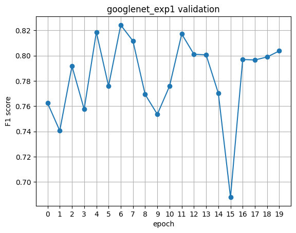

```python
experiment(googlenet_exp1)
```

```
Epoch 1: Train time 11.00 s, Train Accuracy 0.65, Validation time 4.93 s, Validation F1 0.66, Validation Accuracy 0.73
Epoch 2: Train time 10.46 s, Train Accuracy 0.86, Validation time 5.10 s, Validation F1 0.75, Validation Accuracy 0.80
Epoch 3: Train time 10.76 s, Train Accuracy 0.92, Validation time 4.62 s, Validation F1 0.75, Validation Accuracy 0.78
Epoch 4: Train time 11.06 s, Train Accuracy 0.96, Validation time 4.55 s, Validation F1 0.76, Validation Accuracy 0.79
Epoch 5: Train time 11.51 s, Train Accuracy 0.98, Validation time 4.47 s, Validation F1 0.74, Validation Accuracy 0.78
Epoch 6: Train time 11.17 s, Train Accuracy 0.97, Validation time 4.49 s, Validation F1 0.75, Validation Accuracy 0.78
Epoch 7: Train time 10.98 s, Train Accuracy 0.98, Validation time 5.01 s, Validation F1 0.81, Validation Accuracy 0.84
Epoch 8: Train time 10.79 s, Train Accuracy 0.98, Validation time 5.04 s, Validation F1 0.75, Validation Accuracy 0.79
Epoch 9: Train time 10.98 s, Train Accuracy 0.99, Validation time 4.52 s, Validation F1 0.73, Validation Accuracy 0.77
Epoch 10: Train time 11.09 s, Train Accuracy 0.99, Validation time 4.36 s, Validation F1 0.75, Validation Accuracy 0.78
Epoch 11: Train time 11.20 s, Train Accuracy 0.99, Validation time 4.43 s, Validation F1 0.75, Validation Accuracy 0.79
Epoch 12: Train time 11.08 s, Train Accuracy 0.99, Validation time 4.40 s, Validation F1 0.78, Validation Accuracy 0.82
Epoch 13: Train time 11.12 s, Train Accuracy 0.99, Validation time 4.92 s, Validation F1 0.74, Validation Accuracy 0.77
Epoch 14: Train time 10.56 s, Train Accuracy 0.99, Validation time 5.02 s, Validation F1 0.76, Validation Accuracy 0.80
Epoch 15: Train time 10.71 s, Train Accuracy 0.99, Validation time 4.72 s, Validation F1 0.74, Validation Accuracy 0.78
Epoch 16: Train time 11.03 s, Train Accuracy 0.98, Validation time 4.42 s, Validation F1 0.76, Validation Accuracy 0.79
Epoch 17: Train time 11.23 s, Train Accuracy 0.98, Validation time 4.43 s, Validation F1 0.76, Validation Accuracy 0.79
Epoch 18: Train time 11.36 s, Train Accuracy 0.99, Validation time 4.47 s, Validation F1 0.74, Validation Accuracy 0.78
Epoch 19: Train time 11.62 s, Train Accuracy 0.99, Validation time 5.14 s, Validation F1 0.73, Validation Accuracy 0.77
Epoch 20: Train time 10.79 s, Train Accuracy 0.99, Validation time 5.40 s, Validation F1 0.74, Validation Accuracy 0.78
Test Accuracy: 0.82
Test F1: 0.790865224262027
```

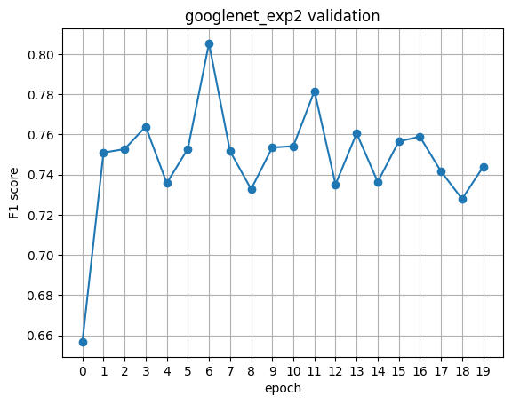

```python
experiment(googlenet_exp2)
```

## Диаграммы

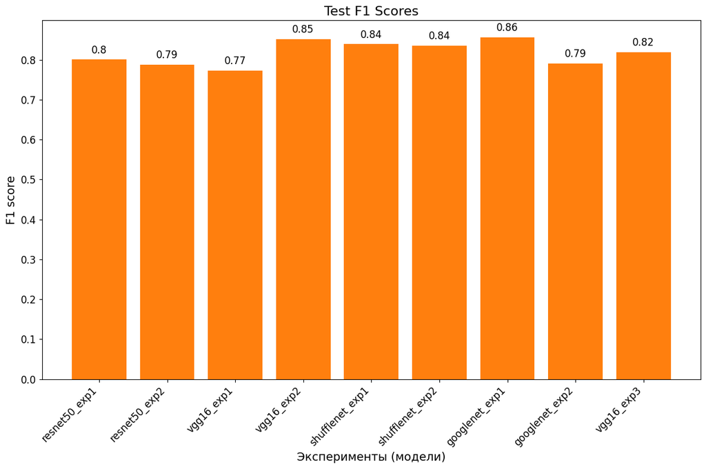

```python
model_names = [*test_f1_stat.keys()]
f1_scores = [*test_f1_stat.values()]

plt.figure(figsize=(12, 8))

colors = ['#ff7f0e']
bars = plt.bar(model_names, f1_scores, color=colors)

plt.xlabel("Эксперименты (модели)", fontsize=14)
plt.ylabel("F1 score", fontsize=14)
plt.title("Test F1 Scores", fontsize=16)

for bar in bars:
    yval = bar.get_height()
    plt.text(bar.get_x() + bar.get_width() / 2, yval + 0.01, round(yval, 2), ha='center', va='bottom', fontsize=12)

plt.xticks(rotation=45, ha="right", fontsize=12)
plt.yticks(fontsize=12)

plt.tight_layout()
plt.show()

# Последний столбец не стоит смотреть, т.к. тестировал модель - удалил ячейку.
```